# R10342008_新聞所碩一_何家慈-Midterm-Assignment

新聞所碩一_何家慈

2022/4/25

```r
options(stringsAsFactors = F)
options(scipen = 999)
library(tidyverse)
library(lubridate)
```

```r
### 繪圖字型處理
##### From Teacher's Code
#th <-
#  theme(title = element_text(family="Heiti TC Light"),
#        text = element_text(family="Heiti TC Light"),
#        axis.text.y = element_text(family="PingFang TC"),
#        axis.text.x = element_text(family="Heiti TC Light"),
#        legend.text = element_text(family="Heiti TC Light"),
#        plot.title = element_text(family="Heiti TC Light")
#        )

##### From My Own

library(showtext)
showtext.auto(enable = TRUE)
```

```
## 'showtext.auto()' is now renamed to 'showtext_auto()'
## The old version still works, but consider using the new function in future code
```

```r
font_add("jf-openhuninn", "jf-openhuninn-1.1.ttf")
font_add("GenJyuuGothicL-Medium", "GenJyuuGothicL-Medium.ttf")
font_add("GenJyuuGothicL-P-Bold", "GenJyuuGothicL-P-Bold.ttf")


th <-
  theme(plot.title = element_text(family="GenJyuuGothicL-P-Bold"),
        plot.subtitle = element_text(family="GenJyuuGothicL-Medium"),
        text = element_text(family="jf-openhuninn"),
        axis.text.y = element_text(family="jf-openhuninn"),
        axis.text.x = element_text(family="jf-openhuninn"),
        legend.text = element_text(family="jf-openhuninn"),
        )
```

# 資料簡述

## 點出該資訊圖表的敘事方式

> 例如，其如何透過圖表選擇、座標軸的選擇、顏色的採用、圖表上的標記來凸顯其新聞敘事。以RMD撰寫、輸出為HTML。

該篇文章是要探討歷年來（2001年至2017年）全美國（整體）及美國各州（局部）的發電燃料來源，畫出stacked area plot，此外會依照比例由高至低排，因此可以看到報導圖中，若有某種發電燃料來源比例激增，該區塊變會竄升至圖表上方，反之亦然。這樣的操作可有助於了解每個發電燃料來源在該年度的發電占比，以及歷年來的升降幅度。

顏色採用部分，NYT似乎有盡量採用該燃料「類似」的顏色，如Coal（煤炭）使用土灰色、水力發電使用淺藍色等，但也只是大致如此。

座標軸部分，橫軸使用年度，縱軸使用「發電占比」，因此此系列圖僅能比較並瞭解各年度、各個發電燃料來源於整體之間的佔比，不能了解總體發電「量」的多寡。

此外，透過網頁敘事手法的疊圖，更能「動態」比較各州發電比例。 NYT網頁：https://www.nytimes.com/interactive/2018/12/24/climate/how-electricity-generation-changed-in-your-state.html

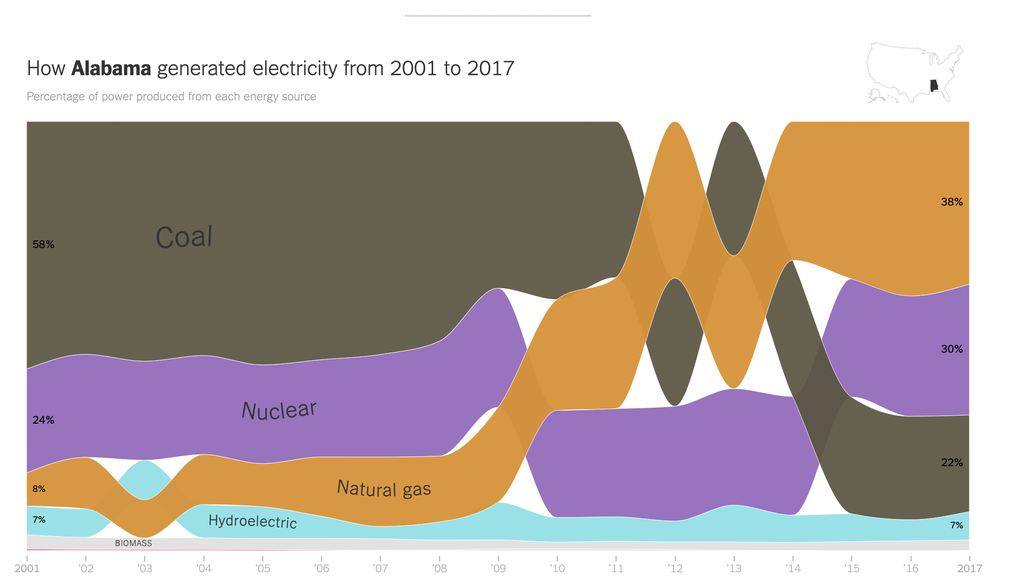

本份資料視覺化作業，僅能製作area plot，還無法製作如上述這種依照名次比例排序的功能。

## 台灣v.s.美國資料差異

本次找到的台灣的資料是從政府開放資料下載而來，有每個月的發電資料，然而因為台灣的發電有分台電本身（發電業）及自用發電設備，因此資料還需要加以處理（數值相加），此外，該表除了「供給量」，其實也有「發電需求量」的欄位，也是一個值得使用的欄位，只是並非本次討論範圍之中。

美國資料同樣也有每個月的發電資料，且單位也與台灣使用的相同（1000MWh = 百萬度），但是美國因為幅員遼闊，可能以各州之發電燃料來源之資料可能較有新聞意義。

# 資料處理與視覺化 - 美國資料

資料來源：https://www.eia.gov/electricity/data/browser/ ## 資料前處理

```r
raw_us <- read_csv("US_elec.csv")
names(raw_us)
```

```
## [1] "Month"
## [2] "all fuels (utility-scale) thousand megawatthours"
## [3] "coal thousand megawatthours"
## [4] "natural gas thousand megawatthours"
## [5] "nuclear thousand megawatthours"
## [6] "conventional hydroelectric thousand megawatthours"
## [7] "wind thousand megawatthours"
## [8] "all solar thousand megawatthours"
```

```r
cleaned_us <- raw_us %>%
  drop_na() %>%
  select(
    time     = Month,
    coal     = `coal thousand megawatthours`,
    gas      = `natural gas thousand megawatthours`,
    nuclear  = `nuclear thousand megawatthours`,
    water    = `conventional hydroelectric thousand megawatthours`,
    wind     = `wind thousand megawatthours`,
    solar    = `all solar thousand megawatthours`
  ) %>%
  mutate(
    month = substr(time, 1,3),
    year  = substr(time, 5,8)
  ) %>%
  gather(
    key="energy source",
    value="electricity production",
    coal, gas,  nuclear, solar, wind, water
  ) %>%
  arrange(year, month) %>%
  group_by(year, `energy source`) %>%
  summarize(
    `electricity production` = round( mean(`electricity production`), 1),
    n = sum(`electricity production`)
  )%>%
  mutate(percentage = round(100* n / sum(n), 1) ) %>%
  ungroup() %>%
  select(
    year, `energy source`, `electricity production`, percentage
  ) %>%
  mutate(year=as.integer(year))
cleaned_us
```

```
## # A tibble: 54 × 4
##     year `energy source` `electricity production` percentage
##    <int> <chr>                              <dbl>      <dbl>
##  1  2013 coal                             157097.       43.4
##  2  2013 gas                               91061.       25.1
##  3  2013 nuclear                           73163.       20.2
##  4  2013 solar                              1375.        0.4
##  5  2013 water                             21634.        6
##  6  2013 wind                              17911.        4.9
##  7  2014 coal                             129755.       39.3
##  8  2014 gas                               94770.       28.7
##  9  2014 nuclear                           66523.       20.1
## 10  2014 solar                              2454.        0.7
## # … with 44 more rows
```

## 繪圖

### 繪製發電量圖 - area plot

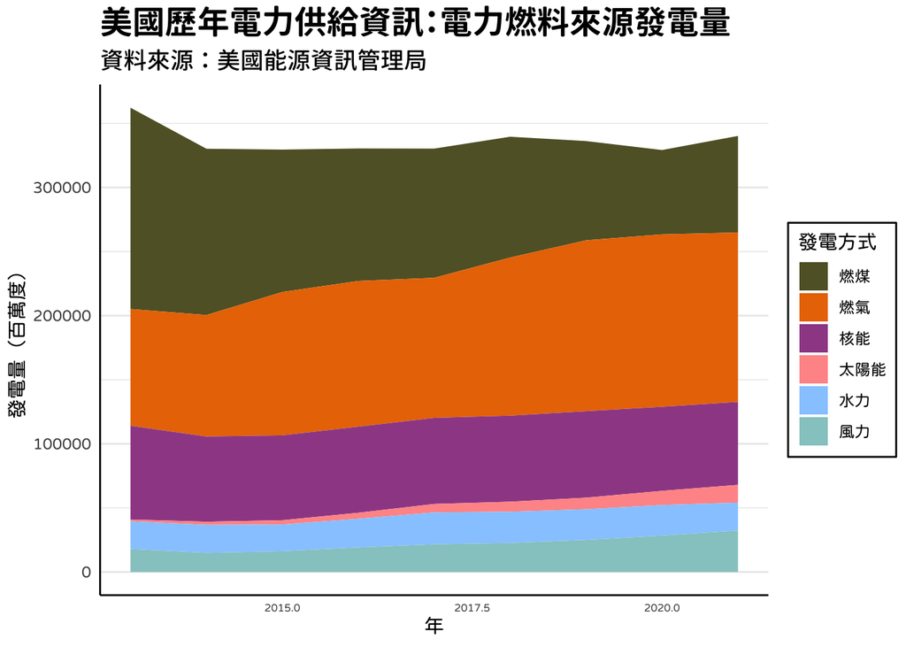

```r
cleaned_us %>%
  ggplot() +
  aes(
    x = year,
    y = `electricity production`,
    fill  = `energy source`
  ) +
  geom_area() +
  labs(title = "美國歷年電力供給資訊：電力燃料來源發電量",
         subtitle = "資料來源：美國能源資訊管理局",
         x = "年",
         y = "發電量（百萬度）",
       ) +
  scale_fill_manual(
    name="發電方式",
    #guide = TRUE,
    label = c(
      'coal'       =  "燃煤",
      'gas'        =  "燃氣",
      'nuclear'    =  "核能",
      'solar'      =  "太陽能",
      'water'      =  "水力",
      'wind'       =  "風力"
    ),
    values= c(
      'coal'       =  "#616130",
      'gas'        =  "#EA7500",
      'nuclear'    =  "#9F4D95",
      'solar'      =  "#FF9797",
      'water'      =  "#97CBFF",
      'wind'       =  "#95CACA"
    ),
  ) +
  ### 圖表主題
  theme_minimal() +
  theme(
    plot.title = element_text(size=18),
    plot.subtitle = element_text(size=13),
    legend.position="right",
    legend.background = element_rect(colour = 'black', fill = 'white', linetype='solid'),
    #legend.title = element_blank(),
    panel.grid.minor.x = element_blank(),
    panel.grid.major.x = element_blank(),
    axis.line.x = element_line(colour = "black"),
    axis.text.x = element_text(size=6),
    axis.line.y = element_line(colour = "black"),

  ) + th
```

### 繪製發電量比例圖 - area plot

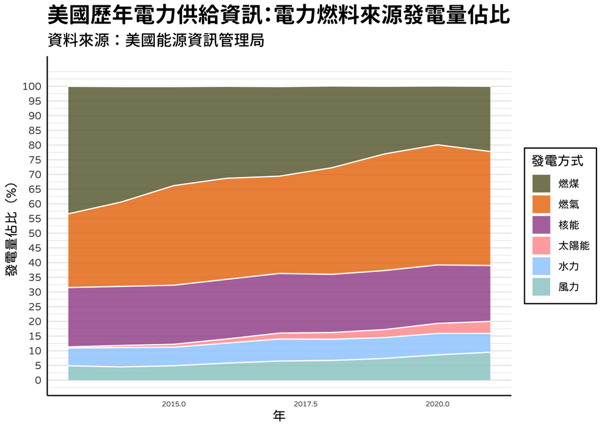

```r
cleaned_us %>%
  ggplot() +
  aes(
    x = year,
    y = percentage,
    fill=`energy source`,
    #labels='a'
  ) +
  geom_area(
    alpha = 0.8,
    size = 0.5,
    color = "white"
  ) +
  labs(title = "美國歷年電力供給資訊：電力燃料來源發電量佔比",
         subtitle = "資料來源：美國能源資訊管理局",
         x = "年",
         y = "發電量佔比（%）",
       ) +
  scale_y_continuous( breaks = seq(0,100,5), limits = c(0, 105) ) +
  scale_fill_manual(
    name="發電方式",
    #guide = TRUE,
    label = c(
      'coal'       =  "燃煤",
      'gas'        =  "燃氣",
      'nuclear'    =  "核能",
      'solar'      =  "太陽能",
      'water'      =  "水力",
      'wind'       =  "風力"
    ),
    values= c(
      'coal'       =  "#616130",
      'gas'        =  "#EA7500",
      'nuclear'    =  "#9F4D95",
      'solar'      =  "#FF9797",
      'water'      =  "#97CBFF",
      'wind'       =  "#95CACA"
    ),
  ) +
  ### 圖表主題
  theme_minimal() +
  theme(
    plot.title = element_text(size=18),
    plot.subtitle = element_text(size=13),
    legend.position="right",
    legend.background = element_rect(colour = 'black', fill = 'white', linetype='solid'),
    #legend.title = element_blank(),
    panel.grid.minor.x = element_blank(),
    panel.grid.major.x = element_blank(),
    axis.line.x = element_line(colour = "black"),
    axis.text.x = element_text(size=6),
    axis.line.y = element_line(colour = "black"),

  ) + th
```

資料整理後可發現，美國資料相對於下方台灣資料，僅有數個發電類別，且無法呈現各州差異性。 此外，可以看到燃煤發電之總發電量佔比逐年降低，燃氣發電之總發電量佔比逐年提高，然該篇報導也指出，燃氣發電僅能作為過渡時期使用，因燃氣發電仍相較於綠能等方式發電，仍屬於較高污染之發電方式。

# 資料處理與視覺化 - 台灣資料

## 資料前處理

### 讀檔案、為每個欄位取英文名稱

```r
raw <- read_csv("elec.csv")
raw <- raw %>%
  select(
    time = `日期(年/月)`,
    total_elec      = 總發電量,
    elec            = 總發電量_發電業,
    pump            = 總發電量_發電業_抽蓄水力,
    fire_all        = 總發電量_發電業_火力,
    fire_coal       = 總發電量_發電業_火力_燃煤,
    fire_oil        = 總發電量_發電業_火力_燃油,
    fire_gas        = 總發電量_發電業_火力_燃氣,
    nuclear         = 總發電量_發電業_核能,
    green_all       = 總發電量_發電業_再生能源,
    green_water     = 總發電量_發電業_再生能源_慣常水力,
    green_floor     = 總發電量_發電業_再生能源_地熱,
    green_sun       = 總發電量_發電業_再生能源_太陽光電,
    green_wind      = 總發電量_發電業_再生能源_風力,
    own             = 總發電量_自用發電設備,
    own_fire_all    = 總發電量_自用發電設備_火力,
    own_fire_coal   = 總發電量_自用發電設備_火力_燃煤,
    own_fire_oil    = 總發電量_自用發電設備_火力_燃油,
    own_fire_gas    = 總發電量_自用發電設備_火力_燃氣,
    own_green_all   = 總發電量_自用發電設備_再生能源,
    own_green_floor = 總發電量_自用發電設備_再生能源_地熱,
    own_green_sun   = 總發電量_自用發電設備_再生能源_太陽光電,
    own_green_wind  = 總發電量_自用發電設備_再生能源_風力,
    own_green_bioe  = 總發電量_自用發電設備_再生能源_生質能,
    own_green_trash = 總發電量_自用發電設備_再生能源_廢棄物


  )
```

## 重新整理表格

因為原先的表格中，會將公有發電與私有發電分開，我們須依照「發電種類」做分別，因此做一些調整，如太陽能發電有分公有與自營，就會將兩者相加。

```r
cleaned <- raw %>%
  mutate(
    year        = as.character(time) %>% substr(1,4) %>% as.integer() ,
    month       = as.character(time) %>% substr(5,6) %>% as.integer()  ,
    YMtime      = paste(as.character(year), as.character(month), sep="-"),
    coal        = fire_coal + own_fire_coal,
    oil         = fire_oil  + own_fire_oil,
    gas         = fire_gas  + own_fire_gas,
    solar       = green_sun + own_green_sun,
    wind        = green_wind + own_green_wind,
    geothermal  = green_floor + own_green_floor,
    water       = green_water
  ) %>%
  select(
    year, month, YMtime, coal, oil, gas, pump, nuclear, solar, wind, geothermal, water
  )
```

## 繪製長表格

利用`gather`函數繪製長表格，並將每個年度進行年平均，作為該年度的數據，並計算電力個發電種類發電量比例。

```r
cleaned_gather <- cleaned %>%
  gather(
    key="energy source",
    value="electricity production",
    coal, oil, gas, pump, nuclear, solar, wind, geothermal, water
  ) %>%
  arrange(year, month) %>%
  group_by(year, `energy source`) %>%
  summarize(
    `electricity production` = round( mean(`electricity production`), 1),
    n = sum(`electricity production`)
  )%>%
  mutate(percentage = round(100* n / sum(n), 1) ) %>%
  ungroup() %>%
  select(
    year, `energy source`, `electricity production`, percentage
  )
# 把2022年資料去掉
cleaned_gather <- cleaned_gather %>%
  head(nrow(cleaned_gather)-9)
```

## 畫圖

### 繪製發電量圖 - area plot

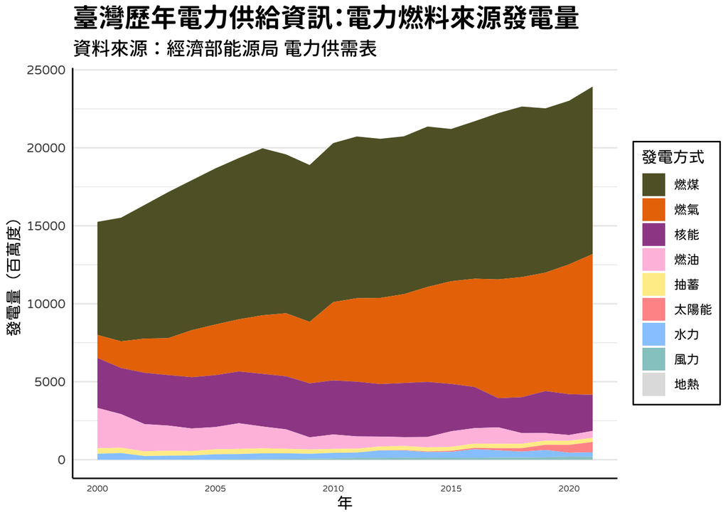

```r
cleaned_gather %>%
  ggplot() +
  aes(
    x = year,
    y = `electricity production`,
    fill  = `energy source`
  ) +
  geom_area() +
  labs(title = "臺灣歷年電力供給資訊：電力燃料來源發電量",
         subtitle = "資料來源：經濟部能源局 電力供需表",
         x = "年",
         y = "發電量（百萬度）",
       ) +
  scale_fill_manual(
    name="發電方式",
    #guide = TRUE,
    label = c(
      'coal'       =  "燃煤",
      'gas'        =  "燃氣",
      'nuclear'    =  "核能",
      'oil'        =  "燃油",
      'pump'       =  "抽蓄",
      'solar'      =  "太陽能",
      'water'      =  "水力",
      'wind'       =  "風力",
      'geothermal' =  "地熱"
    ),
    values= c(
      'coal'       =  "#616130",
      'gas'        =  "#EA7500",
      'nuclear'    =  "#9F4D95",
      'oil'        =  "#FFC1E0",
      'pump'       =  "#FFED97",
      'solar'      =  "#FF9797",
      'water'      =  "#97CBFF",
      'wind'       =  "#95CACA",
      'geothermal' =  "#E0E0E0"
    ),
  ) +
  ### 圖表主題
  theme_minimal() +
  theme(
    plot.title = element_text(size=18),
    plot.subtitle = element_text(size=13),
    legend.position="right",
    legend.background = element_rect(colour = 'black', fill = 'white', linetype='solid'),
    #legend.title = element_blank(),
    panel.grid.minor.x = element_blank(),
    panel.grid.major.x = element_blank(),
    axis.line.x = element_line(colour = "black"),
    axis.text.x = element_text(size=6),
    axis.line.y = element_line(colour = "black"),

  ) + th
```

### 繪製發電量比例圖 - area plot

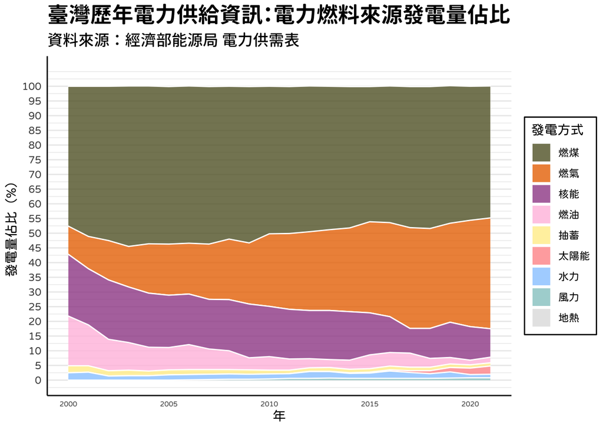

```r
cleaned_gather %>%
  ggplot() +
  aes(
    x = year,
    y = percentage,
    fill=`energy source`,
    #labels='a'
  ) +
  geom_area(
    alpha = 0.8,
    size = 0.5,
    color = "white"
  ) +
  labs(title = "臺灣歷年電力供給資訊：電力燃料來源發電量佔比",
         subtitle = "資料來源：經濟部能源局 電力供需表",
         x = "年",
         y = "發電量佔比（%）",
       ) +
  scale_y_continuous( breaks = seq(0,100,5), limits = c(0, 105) ) +
  scale_fill_manual(
    name="發電方式",
    #guide = TRUE,
    label = c(
      'coal'       =  "燃煤",
      'gas'        =  "燃氣",
      'nuclear'    =  "核能",
      'oil'        =  "燃油",
      'pump'       =  "抽蓄",
      'solar'      =  "太陽能",
      'water'      =  "水力",
      'wind'       =  "風力",
      'geothermal' =  "地熱"
    ),
    values= c(
      'coal'       =  "#616130",
      'gas'        =  "#EA7500",
      'nuclear'    =  "#9F4D95",
      'oil'        =  "#FFC1E0",
      'pump'       =  "#FFED97",
      'solar'      =  "#FF9797",
      'water'      =  "#97CBFF",
      'wind'       =  "#95CACA",
      'geothermal' =  "#E0E0E0"
    ),
  ) +
  ### 圖表主題
  theme_minimal() +
  theme(
    plot.title = element_text(size=18),
    plot.subtitle = element_text(size=13),
    legend.position="right",
    legend.background = element_rect(colour = 'black', fill = 'white', linetype='solid'),
    #legend.title = element_blank(),
    panel.grid.minor.x = element_blank(),
    panel.grid.major.x = element_blank(),
    axis.line.x = element_line(colour = "black"),
    axis.text.x = element_text(size=6),
    axis.line.y = element_line(colour = "black"),

  ) + th
```

資料整理後可發現，台灣資料提供較多發電類別資訊。 值得一提，台灣從2020年至今，每年總發電量逐年攀升，與美國總發電量持平有所差異。 另外，可以看到燃煤發電之總發電量佔比近年來逐年微幅降低，燃氣發電之總發電量佔比逐年提高（與美國同），然而台灣的核能發電近年來佔比逐年降低，太陽能發電佔比逐年提高，應與當前蔡英文政府w推動之能源政策有關（燃氣50%-燃煤30%-綠能20%）。

```r
save(raw, cleaned, cleaned_gather, file = "elecData_tw.rda")
save(raw_us, cleaned_us, file = "elecData_us.rda")
```